# BIOL361 Prac 2 — GIS in R

Dr James B Dorey, University of Wollongong

Version 2025-02-25; practical 2025-03-31

Abstract

Today we will go through some geographical information system (GIS) code and analyses in **R**. This will involve (1) learning some GIS data basics, (2) reading in and plot GIS data, and (3) running some simple analyses.

# 1 GIS data basics

People are often quite intimidated by working with any data, let alone specialised datasets and formats! Even **Excell** data formats can be scary if you’re so inclined. So, I’ll try to dispell some of your fears in this section as even “complex” data can be demistified. Much of the data that we are going to be using isn’t *actually* complex!

## 1.1 Raster and vector data

Alright, so I know that I said our data weren’t complex and then I threw two random and scary-sounding words at you. Well, don’t stress I’ll break it down and also point out that *raster* and *vector* data are also regularly used by most of us on a daily basis! In the shortest terms possible… *raster* data are matrices/tables of data and vector data are simply points and lines.

### 1.1.1 Raster data (matrices or tables)

One of the most-commonly known raster file formats would be the *.jpg* format. But, many others are commonly used, such as *.tiff*, *.png*, and *.gif*. You might be wondering “How on Earth is that a matrix or table??”. And loo, fair enough. But take a look at the below dplyr logo. This is a *.png* file, and if we zoom in, we can start to see the pixels which are actualyl just cells of a matrix that are filled with colour! This logo has a resolution of 240x277 (66,480) pixels.

[figure not shown]

**The *dplyr* logo with an inset showing the pixels, or the cells of a raster matrix**

### 1.1.2 Vector data (points and lines)

Vector data formats are even simpler, I think than raster data formats. Once again, you are all familiar with these formats! Probably the most-common one would be the *.pdf* format. But others exist like *.svg* and *.shp*. Vector file formats **do not have pixels** at all, which actually has some benefits. This means that we can keep zooming and zooming in on a vector file (just as we did above) and we will never see pixels!

Below, you can see a cutout of a *.pdf* map file which has vector data (letters, numbers, points, and lines) as well as raster data embedded (a raster map of elevation). On the left hand side you can see that we can zoom into the 18ºS and the lines without any pixels appearing. But, on the right hand side, you cna see that the lines of the map remain clear but the pixels of the map begin to appear!

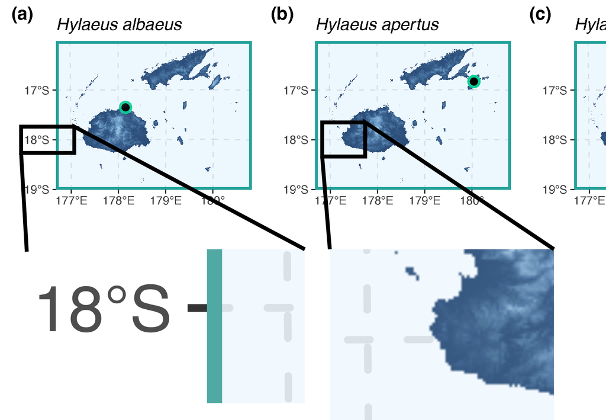

**Two map figures with insets showing the impact of zooming into vector and raster data.**

## 1.2 Projections

This is something that is better covered in another topic, but very briefly… The earth is more or less a sphere, but quite often we want to represent this sphere on a flat surface (a map). Most of the time, if we zoom in enough this isn’t really a problem! However, the further out that we zoom the more and more problematic this is! For that reason we “**project**” that round map onto a flat surface. These are “**Projected Coordinate Systems**”.

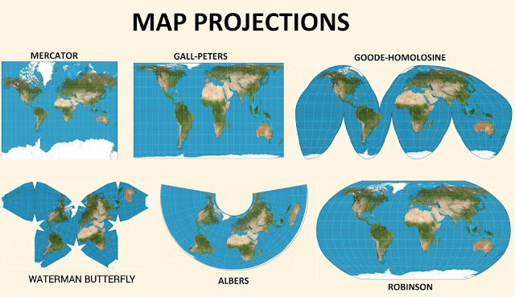

**Several projected coordiante systems.**

[Image from here](https://practicalgeoskills.blogspot.com/2020/04/map-projections-meaning-and-examples.html)

It’s clear that these projection are visually very… diverse. This becomes a problem when you’re doing analyses or trying to make maps! In this prac we will mostly circumvent this issue by using a “**Geographic [3D] Coordinate System**” like WGS84 (below).

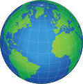

**WGS84 is a 3D geographic coordinate system that does away with projection issues (untill you want to show your map on a flat page again!).**

[Image from here](https://en.wikipedia.org/wiki/World_Geodetic_System)

# 2 Script preparation

## 2.1 Install and load packages

Set you working directory again. This can be the same as last week’s or a new one — up to you!

```r
  # Set the RootPath to your folder
RootPath <- "/Users/jamesdorey/Desktop/Uni/Teaching/BIOL361/Lectures/2025/Github_BIOL361_25/BIOL361_25/DoreyPrac1"
  # You can then set this as the project's working directory.
  # This is where R will first look to find
  # or save data as a default
setwd(RootPath)
```

These are the **NEW** packages that we will use this week. If you have lost those from last week, go back and install them as well. Although, below we will also install some GIS packages.

```r
install.packages("geodata")
install.packages("tidyterra")
```

Load all of the packages from this week and last week into **R**.

```r
library(dplyr)
library(readr)
library(magrittr)
library(stringr)
library(ggplot2)
library(geodata)
library(tidyterra)
```

## 2.2 GIS in *R* formats and packages

Different GIS programs tend to have different file formats. **ArcMap** is the most cagey (as it’s a proprietary program) and so has a bunch of annoying proprietary file formats. **QGIS** is open source and tends to use some simpler formats (yay!). **R** is more-or-less able to open any of those formats and read them in (even more yay!). Let’s install the needed packages and have a very short discussion of their [preferred] formats.

> “**Raster** data divide space into *rectangular grid cells* and they are commonly used to represent spatially continuous phenomena, such as elevation or the weather. Satellite images also have this data structure, and in that context grid cells are often referred to as pixels. In contrast, **vector** spatial data (*points, lines, polygons*) are typically used to represent discrete spatial entities, such as a road, country, or bus stop.”

**Attention:**  
Annoyingly, the first time that you use **terra** or **sf** on a new computer you may need to install some dependencies. Try to install the **terra** and **sf** packages first but then come back here if that doesn’t work.

**Windows:**  
On **Windows**, you need to first install [Rtools](https://cran.r-project.org/bin/windows/Rtools/) to get a C++ compiler that **R** can use. You need a recent version of **Rtools42** (rtools42-5355-5357).

**MacOS:**  
On **macOS**, you can use [MacPorts](https://www.macports.org/) or [Homebrew](https://brew.sh/).

With **MacPorts** you can do

`sudo port install R-terra`

With **Homebrew**, you need to first install GDAL:

`brew install pkg-config`

`brew install gdal`

Followed by (note the additional configuration argument needed for Homebrew)

```r
  # Install terra
install.packages("terra", type = "source", configure.args = "--with-proj-lib=$(brew --prefix)/lib/")
  # install sf
install.packages("sf", type = "source", configure.args = "--with-proj-lib=$(brew --prefix)/lib/")
```

### 2.2.1 *terra* (formerly *raster*)

The [**terra**](https://rspatial.github.io/terra/index.html) package is mostly used to deal with raster data, but has some ability to work with vector data as well. *(It was also formerly called **raster**.)*

The **terra** package has two main data types, simply called **SpatRaster** and **SpatVector**. *(along with some minor types.)*

### 2.2.2 *sf* (formerly *sp*)

The [**sf**](https://r-spatial.github.io/sf/), or *simple feature* package (formerly **sp**) mainly works with vector data. That’s to say that by-and-large, it works with points and lines. However, it does have some abilities to use raster as well.

By and large, **sf** works with *data frames* and *tibbles* (the latter is what we make with `readr::read_csv()`!). Essentially, it stores the spatial data in an easily human-readable table!

# 3 Read and plot data

Okay, maybe that’s enough faffing around! There’s more to know about GIS, but this isn’t the place to learn it all. I just want to give you a brief overview of what’s possible to do in R so that in your future careers you’ll be able to do some amazing thigns for conservation biology! We have talked a lot about these data types, and now I think it’s past time to get to work with them!

## 3.1 Raster

We can often find raster datasets from government, non-governmental, and other websites and datasets. You can spend ages looking around online for the best possible dataset to download and apply towards a conservation goal. However, **R** also provides packages that can very easily and quickly read in datasets from the internet!

Below, we will use the **R** package **geodata** to download a Digital Elevation Model (DEM) os the entirity of Australia at a 30-second (~1 km) resolution.

```r
AustralianElevations <- geodata::elevation_30s("Australia",
                               path = RootPath)
  # View a summary of the data
AustralianElevations
```

```
## class       : SpatRaster
## dimensions  : 4296, 5592, 1  (nrow, ncol, nlyr)
## resolution  : 0.008333333, 0.008333333  (x, y)
## extent      : 112.8, 159.4, -44.9, -9.1  (xmin, xmax, ymin, ymax)
## coord. ref. : lon/lat WGS 84 (EPSG:4326)
## source      : AUS_elv_msk.tif
## name        : AUS_elv_msk
## min value   :         -60
## max value   :        2159
```

How about that! Within a few seconds we have a *spatRaster* showing the elevatino across Australia!

> **Q2:** Looking at the summary of *AustralianElevations*, (1) what are the dimensions of the file, (2) what is the coordinate reference system and is it a **projected** or **geographic** coordinate system (see “Projections” above), and (3) what are the minimum and maximum elevational values for this map of Australia?

Let’s go ahead and have a little peak at what our data looks like now as well. Quite often you can just run `terra::plot()` for your map… however, I don’t always recommend this with bigger GIS files as they can freeze your computer. In fact, **ggplot2**, with the help of **tidyterra** does a better job once again!

```
## <SpatRaster> resampled to 500340 cells.
```

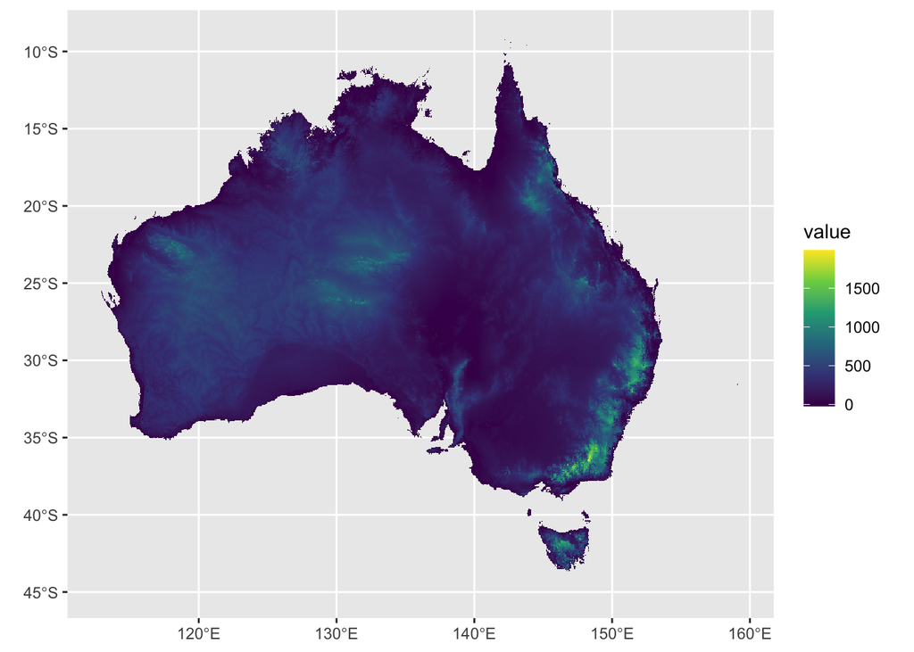

```r
(AusEleMap <- ggplot2::ggplot() +
  tidyterra::geom_spatraster(data = AustralianElevations,
                             ggplot2::aes(fill = AUS_elv_msk)) +
    # Feel free to remove this line (don't leave an open "+" in the previous line) and
    # see what happens! "viridis" is one of MANY colour palettes available with ggplot2
  ggplot2::scale_fill_viridis_c(na.value = "transparent") )
```

Look, I know that I’m a data nerd and all but seriously? Within a few lines of code and a few minutes we have a map of Australia that you could use in a publication or for an analysis? That’s pretty powerful stuff! **BUT**, an elevation map of Australia isn’t necessarrily that interesting by itself… maybe we want some species occurrence data to go with it?